# Bersini_RNAseq quality control of Raw Data

========================== Author: Layal Abo Khayal, PhD **** Edited:on 27.09.2024 ============================

## 1- check the quality of data before trimming

### 1-1 Installing and Running FastQC

The first step is to define the quality of the data by using FastQC on the raw data before trimming the adapters from the sequencing

```r
if(!require(fastqcr)){
  install_github("kassambara/fastqcr")
}
library("fastqcr")
```

#### **Running FastQC from R**

FastQC is a Linux tool, it can be run in the command line. I used this R package to facilitate reading the outputof the files quality

### Aggregating Reports

```r
#Aggregating FastQC reports:
# QC Results directory
qc.dir = "~/Documents/EOC/QC_BT"
qc <- fastqcr::qc_aggregate(qc.dir)
```

```r
qc
```

[output not shown]

[output cut: 122 more lines]

```r
NA
```

#### Summarizing Reports

We start by presenting a summary and general statistics of the aggregated data.

```r
summary(qc)
```

[output not shown]

| module | nb_samples | nb_fail | nb_pass | failed |
| --- | --- | --- | --- | --- |
| Adapter Content | 12 | 12 | 0 | OB_10_red_ribozero_S3_L001_R1_001, OB_11_red_ribozero_S4_L001_R1_001, OB_12_red_ribozero_S5_L001_R1_001, OB_13_red_ribozero_S6_L001_R1_001, OB_8_red_ribozero_S1_L001_R1_001, OB_9_red_ribozero_S2_L001_… |
| Basic Statistics | 12 | 0 | 12 | NA |
| Overrepresented sequences | 12 | 12 | 0 | OB_10_red_ribozero_S3_L001_R1_001, OB_11_red_ribozero_S4_L001_R1_001, OB_12_red_ribozero_S5_L001_R1_001, OB_13_red_ribozero_S6_L001_R1_001, OB_8_red_ribozero_S1_L001_R1_001, OB_9_red_ribozero_S2_L001_… |
| Per base N content | 12 | 0 | 12 | NA |
| Per base sequence content | 12 | 12 | 0 | OB_10_red_ribozero_S3_L001_R1_001, OB_11_red_ribozero_S4_L001_R1_001, OB_12_red_ribozero_S5_L001_R1_001, OB_13_red_ribozero_S6_L001_R1_001, OB_8_red_ribozero_S1_L001_R1_001, OB_9_red_ribozero_S2_L001_… |
| Per base sequence quality | 12 | 3 | 9 | OB_8_red_ribozero_S1_L001_R1_001, OB_9_red_ribozero_S2_L001_R1_001, YA_12_blue_ribozero_S9_L001_R1_001 |
| Per sequence GC content | 12 | 12 | 0 | OB_10_red_ribozero_S3_L001_R1_001, OB_11_red_ribozero_S4_L001_R1_001, OB_12_red_ribozero_S5_L001_R1_001, OB_13_red_ribozero_S6_L001_R1_001, OB_8_red_ribozero_S1_L001_R1_001, OB_9_red_ribozero_S2_L001_… |
| Per sequence quality scores | 12 | 0 | 12 | NA |
| Per tile sequence quality | 12 | 12 | 0 | OB_10_red_ribozero_S3_L001_R1_001, OB_11_red_ribozero_S4_L001_R1_001, OB_12_red_ribozero_S5_L001_R1_001, OB_13_red_ribozero_S6_L001_R1_001, OB_8_red_ribozero_S1_L001_R1_001, OB_9_red_ribozero_S2_L001_… |
| Sequence Duplication Levels | 12 | 12 | 0 | OB_10_red_ribozero_S3_L001_R1_001, OB_11_red_ribozero_S4_L001_R1_001, OB_12_red_ribozero_S5_L001_R1_001, OB_13_red_ribozero_S6_L001_R1_001, OB_8_red_ribozero_S1_L001_R1_001, OB_9_red_ribozero_S2_L001_… |

[output cut: 1 more lines]

## Ploting all the modules for all samples

## The precentage of GC content

This module failed in all sample and it shows very high percentage of GC which refers to This module will indicate a failure if the sum of the deviations from the normal distribution represents more than 30% of the readsSharp peaks on an otherwise smooth distribution are normally the result of a specific contaminant (adapter dimers for example), which may well be picked up by the overrepresented sequences module. Broader peaks may represent contamination with a different species. We can decide if the data is contaminated if the GC percentage stay higher than 30% after trimming the adapters

```r
# Plot per sequence GC content
jpeg(filename = "GC content in all files" , width = 800, height = 600 )
fastqcr::qc_plot_collection(qc_readAll, "Per sequence GC content")
dev.off()
```

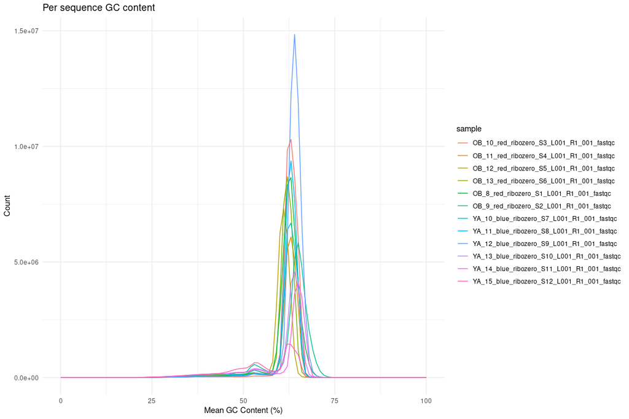

```r
fastqcr::qc_plot_collection(qc_readAll, "Per sequence GC content")
```

## Overrepresented sequences: This the concerns in this data Finding that a single sequence is very overrepresented in the set either means that it is highly biologically significant, or indicates that the library is contaminated, or not as diverse as you expected. This module lists all of the sequence which make up more than 0.1% of the total. To conserve memory only sequences which appear in the first 100,000 sequences are tracked to the end of the file. It is therefore possible that a sequence which is overrepresented but doesn’t appear at the start of the file for some reason could be missed by this module.

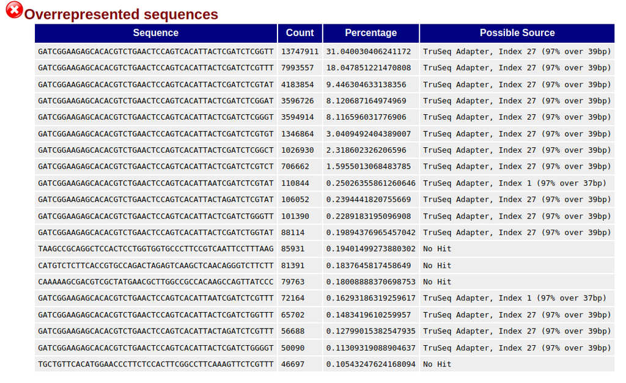

## Plotting the failed modules

From the summary of the aggregated report are:  
1. **Adapter Content**: it is normal to fail because we need to trim the sequencing adapters from the reads. in the following plot how the raw data looks like:

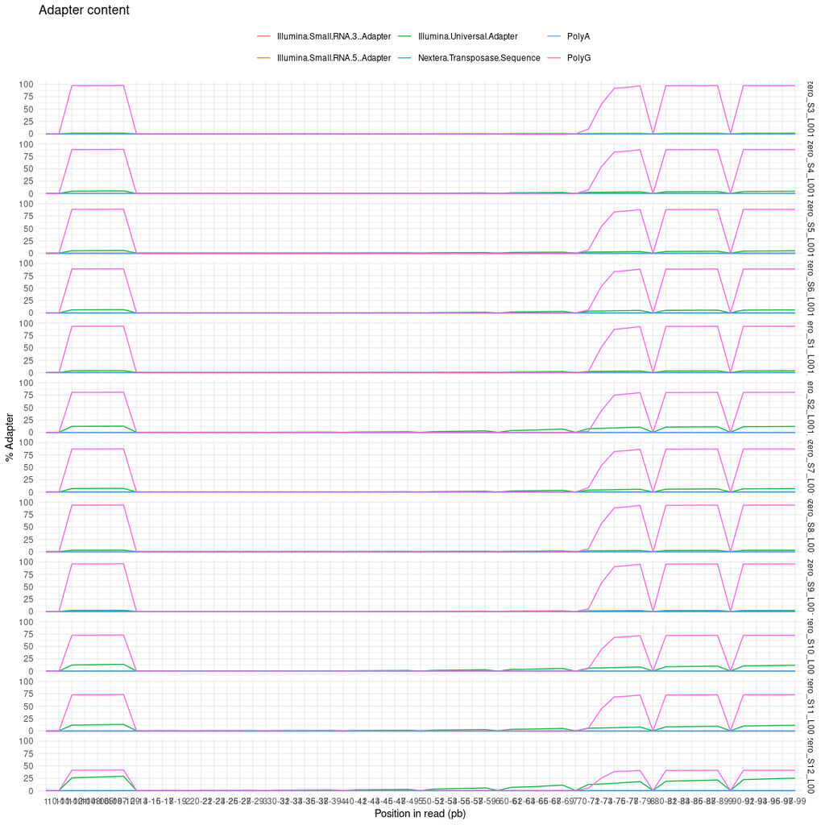

```r
fastqcr::qc_plot_collection(qc_readAll, "Adapter Content")
```

2. **Per Base Sequence Content** : This module will fail if the difference between A and T, or G and C is greater than 20% in any position. it failed in all sample

```r
qc_R1 <- fastqcr::qc_read(qcfiles[1])
```

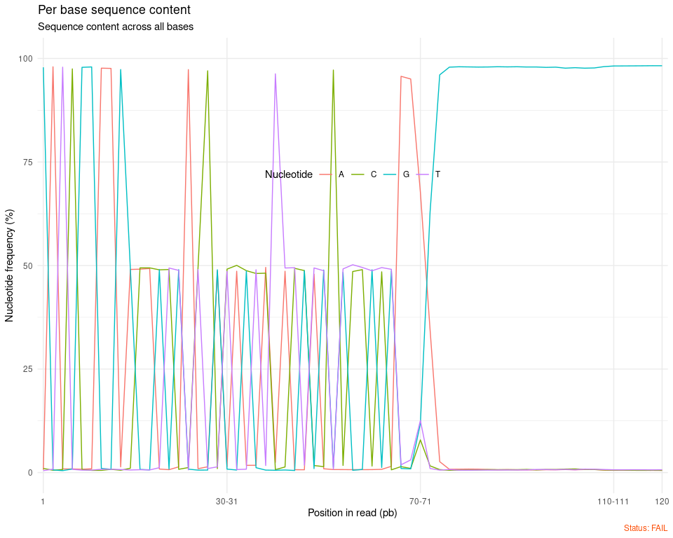

```r
fastqcr::qc_plot(qc_R1, "Per Base Sequence Content" )
```

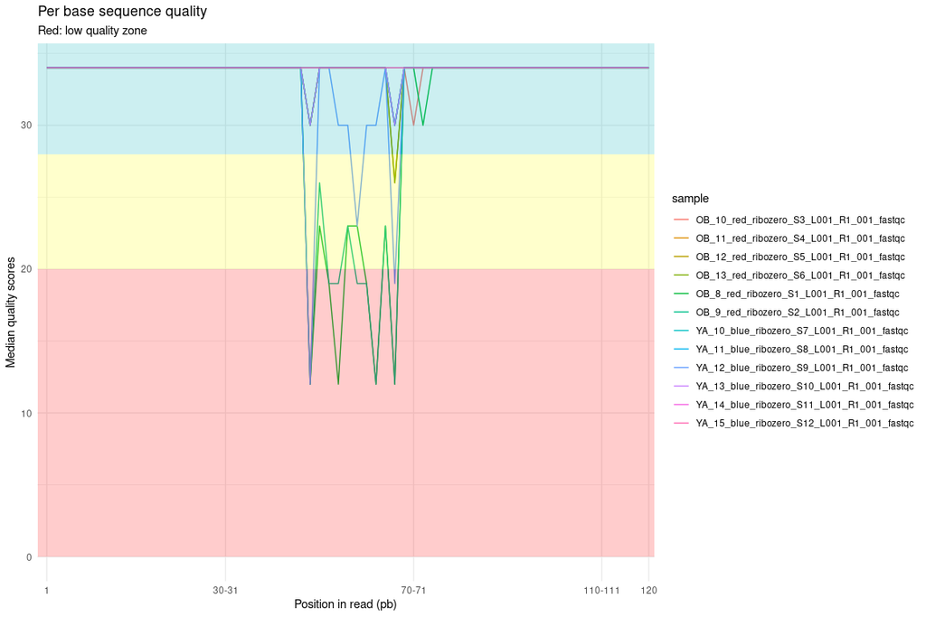

```r
fastqcr::qc_plot_collection(qc_readAll, "Per base sequence quality")
```

#Plot all modules for all Samples

```r
#qcfiles <- list.files(path=qc.dir, pattern="*.zip", full.names=TRUE, recursive=FALSE)
#nb_samples <- length(qcfiles)
#nameQCf <- sub(".zip","", basename(qcfiles))
qcR <- qc_read(qcfiles[1])
mod <- c("Adapter Content","per base sequence quality", "per sequence quality scores" ,"per base sequence content","per sequence gc content","per base n content", "sequence length distribution", "sequence duplication levels" )
```

```r
print(nameQCf[1] )
```

```
[1] "OB_10_red_ribozero_S3_L001_R1_001_fastqc"
```

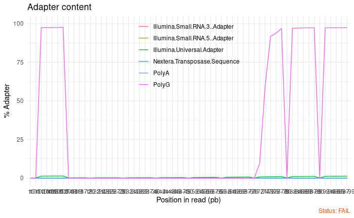

```r
par(mfrow=c(4,2))
fastqcr::qc_plot(qcR, mod[1] )
```

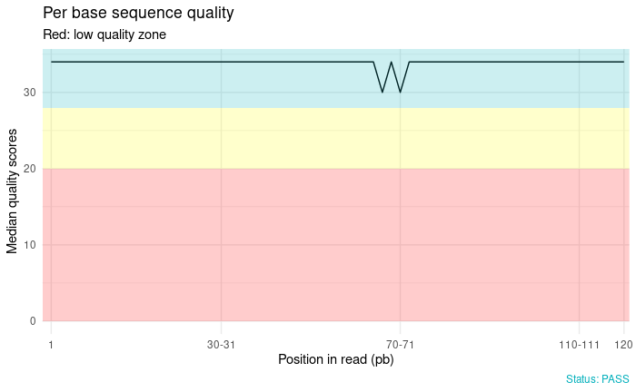

```r
fastqcr::qc_plot(qcR, mod[2] )
```

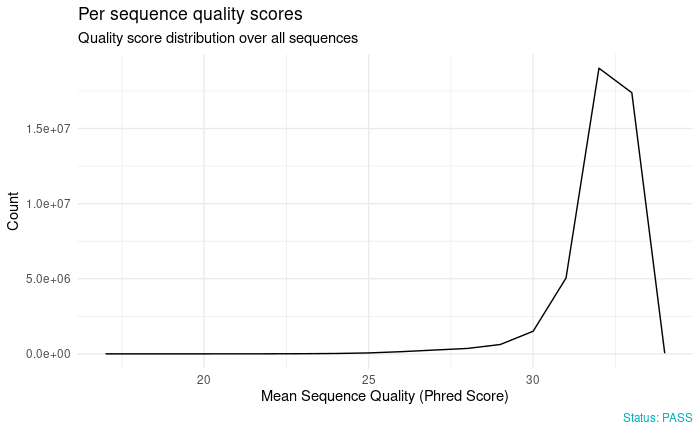

```r
fastqcr::qc_plot(qcR, mod[3] )
```

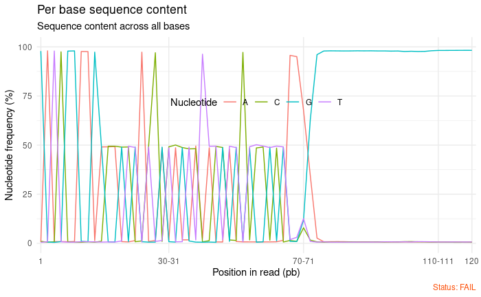

```r
fastqcr::qc_plot(qcR, mod[4] )
```

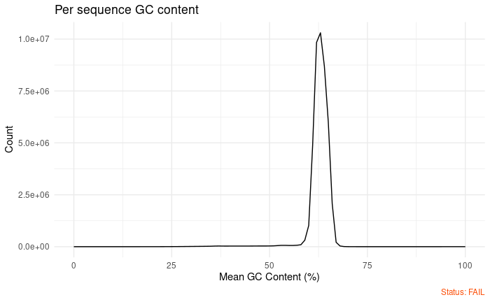

```r
fastqcr::qc_plot(qcR, mod[5] )
```

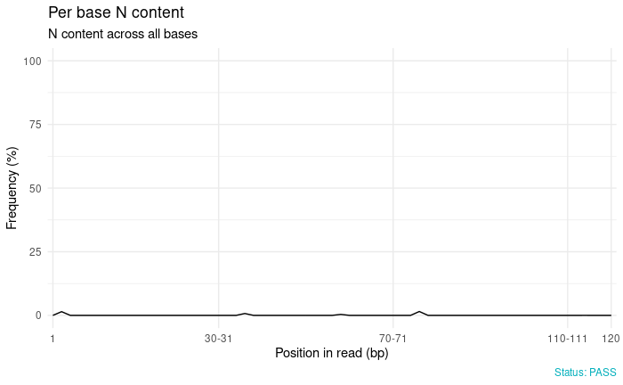

```r
fastqcr::qc_plot(qcR, mod[6] )
```

```
`geom_line()`: Each group consists of only one observation.
ℹ Do you need to adjust the group aesthetic?
```

[figure not shown]

```r
fastqcr::qc_plot(qcR, mod[7] )
```

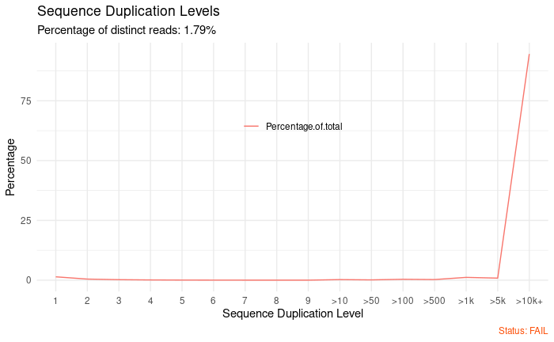

```r
fastqcr::qc_plot(qcR, mod[8] )
```

```r
library(dplyr)
qc %>%
  select(sample, module, status) %>%
  filter(status %in% c("WARN", "FAIL")) %>%
  arrange(sample)
```

| sample | module | status |
| --- | --- | --- |
| OB_10_red_ribozero_S3_L001_R1_001 | Per tile sequence quality | FAIL |
| OB_10_red_ribozero_S3_L001_R1_001 | Per base sequence content | FAIL |
| OB_10_red_ribozero_S3_L001_R1_001 | Per sequence GC content | FAIL |
| OB_10_red_ribozero_S3_L001_R1_001 | Sequence Duplication Levels | FAIL |
| OB_10_red_ribozero_S3_L001_R1_001 | Overrepresented sequences | FAIL |
| OB_10_red_ribozero_S3_L001_R1_001 | Adapter Content | FAIL |
| OB_11_red_ribozero_S4_L001_R1_001 | Per tile sequence quality | FAIL |
| OB_11_red_ribozero_S4_L001_R1_001 | Per base sequence content | FAIL |
| OB_11_red_ribozero_S4_L001_R1_001 | Per sequence GC content | FAIL |
| OB_11_red_ribozero_S4_L001_R1_001 | Sequence Duplication Levels | FAIL |

[output cut: 65 more lines]

### Per Module Problems

#### Modules that failed in the most samples:

```r
qc_fails(qc, "module")
```

| module | nb_problems | sample |
| --- | --- | --- |
| Adapter Content | 12 | OB_10_red_ribozero_S3_L001_R1_001, OB_11_red_ribozero_S4_L001_R1_001, OB_12_red_ribozero_S5_L001_R1_001, OB_13_red_ribozero_S6_L001_R1_001, OB_8_red_ribozero_S1_L001_R1_001, OB_9_red_ribozero_S2_L001_… |
| Overrepresented sequences | 12 | OB_10_red_ribozero_S3_L001_R1_001, OB_11_red_ribozero_S4_L001_R1_001, OB_12_red_ribozero_S5_L001_R1_001, OB_13_red_ribozero_S6_L001_R1_001, OB_8_red_ribozero_S1_L001_R1_001, OB_9_red_ribozero_S2_L001_… |
| Per base sequence content | 12 | OB_10_red_ribozero_S3_L001_R1_001, OB_11_red_ribozero_S4_L001_R1_001, OB_12_red_ribozero_S5_L001_R1_001, OB_13_red_ribozero_S6_L001_R1_001, OB_8_red_ribozero_S1_L001_R1_001, OB_9_red_ribozero_S2_L001_… |
| Per sequence GC content | 12 | OB_10_red_ribozero_S3_L001_R1_001, OB_11_red_ribozero_S4_L001_R1_001, OB_12_red_ribozero_S5_L001_R1_001, OB_13_red_ribozero_S6_L001_R1_001, OB_8_red_ribozero_S1_L001_R1_001, OB_9_red_ribozero_S2_L001_… |
| Per tile sequence quality | 12 | OB_10_red_ribozero_S3_L001_R1_001, OB_11_red_ribozero_S4_L001_R1_001, OB_12_red_ribozero_S5_L001_R1_001, OB_13_red_ribozero_S6_L001_R1_001, OB_8_red_ribozero_S1_L001_R1_001, OB_9_red_ribozero_S2_L001_… |
| Sequence Duplication Levels | 12 | OB_10_red_ribozero_S3_L001_R1_001, OB_11_red_ribozero_S4_L001_R1_001, OB_12_red_ribozero_S5_L001_R1_001, OB_13_red_ribozero_S6_L001_R1_001, OB_8_red_ribozero_S1_L001_R1_001, OB_9_red_ribozero_S2_L001_… |
| Per base sequence quality | 3 | OB_8_red_ribozero_S1_L001_R1_001, OB_9_red_ribozero_S2_L001_R1_001, YA_12_blue_ribozero_S9_L001_R1_001 |

### Per Sample Problems

- **Samples with one or more failed modules**:

```r
# See which samples had one or more failed modules
qc_fails(qc, "sample")
```

| sample | nb_problems | module |
| --- | --- | --- |
| OB_8_red_ribozero_S1_L001_R1_001 | 7 | Per base sequence quality, Per tile sequence quality, Per base sequence content, Per sequence GC content, Sequence Duplication Levels, Overrepresented sequences, Adapter Content |
| OB_9_red_ribozero_S2_L001_R1_001 | 7 | Per base sequence quality, Per tile sequence quality, Per base sequence content, Per sequence GC content, Sequence Duplication Levels, Overrepresented sequences, Adapter Content |
| YA_12_blue_ribozero_S9_L001_R1_001 | 7 | Per base sequence quality, Per tile sequence quality, Per base sequence content, Per sequence GC content, Sequence Duplication Levels, Overrepresented sequences, Adapter Content |
| OB_10_red_ribozero_S3_L001_R1_001 | 6 | Per tile sequence quality, Per base sequence content, Per sequence GC content, Sequence Duplication Levels, Overrepresented sequences, Adapter Content |
| OB_11_red_ribozero_S4_L001_R1_001 | 6 | Per tile sequence quality, Per base sequence content, Per sequence GC content, Sequence Duplication Levels, Overrepresented sequences, Adapter Content |
| OB_12_red_ribozero_S5_L001_R1_001 | 6 | Per tile sequence quality, Per base sequence content, Per sequence GC content, Sequence Duplication Levels, Overrepresented sequences, Adapter Content |
| OB_13_red_ribozero_S6_L001_R1_001 | 6 | Per tile sequence quality, Per base sequence content, Per sequence GC content, Sequence Duplication Levels, Overrepresented sequences, Adapter Content |
| YA_10_blue_ribozero_S7_L001_R1_001 | 6 | Per tile sequence quality, Per base sequence content, Per sequence GC content, Sequence Duplication Levels, Overrepresented sequences, Adapter Content |
| YA_11_blue_ribozero_S8_L001_R1_001 | 6 | Per tile sequence quality, Per base sequence content, Per sequence GC content, Sequence Duplication Levels, Overrepresented sequences, Adapter Content |
| YA_13_blue_ribozero_S10_L001_R1_001 | 6 | Per tile sequence quality, Per base sequence content, Per sequence GC content, Sequence Duplication Levels, Overrepresented sequences, Adapter Content |

[output cut: 2 more lines]